# Organización de un repositorio

Para organizar el procesamiento de la información en los repositorios de GitLab, se empela el flujo de trabajo de [Human Rights Whatch](https://hrdag.org/2016/06/14/the-task-is-a-quantum-of-workflow/) (HRW-WF).

## 1. Acerca de las tareas

HRW-WF está orientado a tareas, es decir, se debe crear una carpeta para cada tarea de limpieza/procesamiento que se realice en el proyecto. Cada carpeta debe contener como mínimo tres carpetas, **input** (contiene los datos originales), **code/source** (contiene el script con el código) y **output** (contiene los datos procesados que resultan de ejecutar el código). Además, los nombres de las carpetas deben iniciar con un número que identifique el orden en el que se debe ejecutar la tarea:

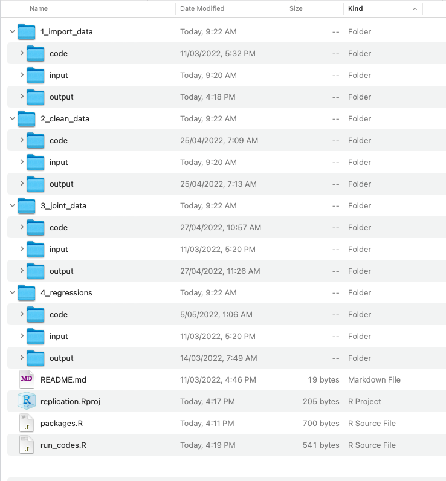

## 2. Acerca de `packages.R`

En este código se deben definir algunas tareas que se deben realizar antes de ejecutar los códigos con las tareas del repositorio.

- **Versión de R:** primero debe especificar la versión de R bajo la que se ejecutaron las tareas del repositorio.
- **Librerías:** se debe verificar si la librería `pacman` está instalada de lo contrario debe instalarse y llamarse. `pacman` contiene la función `p_load()`, la cual permite instalar/llamar todas las librerías necesarias para ejecutar las tareas del repositorio.
- **Funciones y conflictos:** se debe resolver los conflictos con los nombres que se repiten en diferentes librerías. Esto es necesario para evitar que no cometa error en la ejecución de los códigos de las tareas.

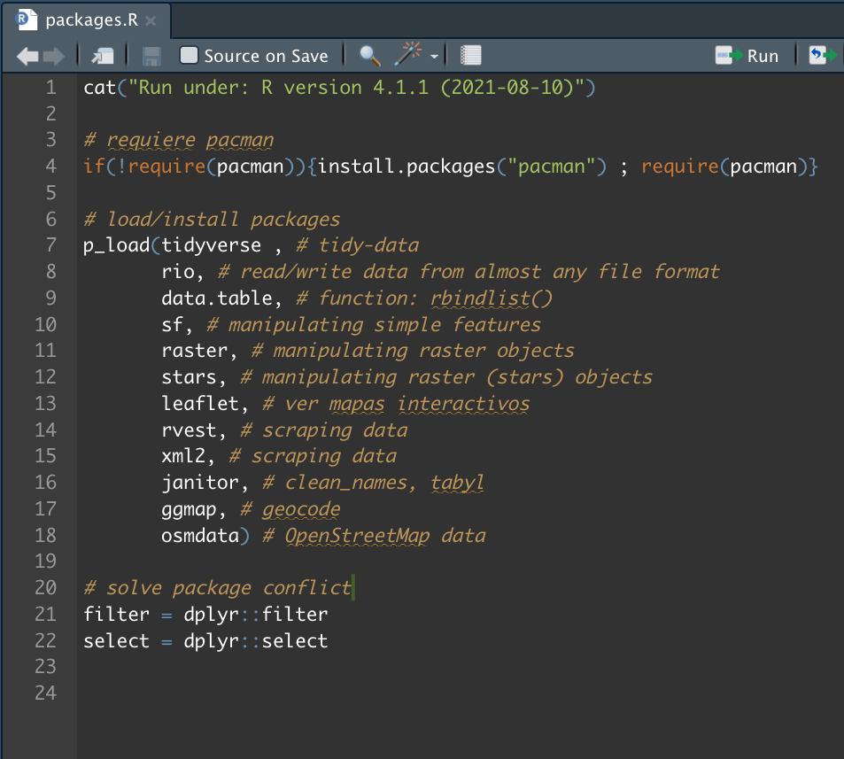

## 3. Acerca de `run_codes.R`

Este código debe contener la limpieza de los directorios de las carpetas `.../output/...` y la ejecución de los códigos de todas las tareas de los repositorios. Lo anterior, para garantizar que los resultados del repositorio son replicables de la primera a la última tarea.

[figure not shown]

**Nota:** algunas tareas que generan un alto costo computacional y/o monetario (descarga de información de google) se pueden omitir de la replicación.

## 4. Acerca de `README.md`

Todos los repositorios deben tener un archivo `README.md` en el que se detalla el objetivo de cada una de las tareas del repositorio. Además, se debe documentar toda la información relevante para el repositorio.

## 5. Nombrar archivos en el output

Los archivos en las carpetas de output deben guardarse así:

**db_unit_descript_period.rds**

**db** = tipo de información que contiene el archivo, por ejemplo: - db: base de datos en dataframe o tible. - ls: base de datos en lista. - sp: conjunto de datos espaciales en formato Sp. - sf: conjunto de datos espaciales en formato SF. - raster: conjunto de datos espaciales en formato raster.

**unit** = Unidad de observación de la base de datos, por ejemplo: - mpio: municipal - village: vereda - grids: grillas - poly: polígono - point: punto - line: línea o arco

**descript** = variable o fuente de la información que, por ejemplo: - night-light: variables de luces nocturnas. - odc: información del observatorio de drogas de Colombia.

**period** = Periodo inicial y final, si es anual se debe escribir solo el año, pero si es mensual se escribe el año y el mes, por ejemplo: - 2010-2020: Información anual desde 2010 hasta 2020 - 201204-202104: Información mensual desde abril de 2012 hasta abril de 2021 - 20120401-20210401: Información mensual desde el 1 de abril de 2012 hasta el 1 de abril de 2021